# Classification Modeling on Online Shoppers Intention Dataset

The total 12330 entries in this data belongs to all different users (i.e. independent). The dataset was formed so that each session would belong to a different user in a 1-year period to avoid any tendency to a specific campaign, special day, user profile, or period.

```python
from sklearn.datasets import load_digits
from sklearn.model_selection import train_test_split

digits = load_digits()
X_train, X_test, y_train, y_test = train_test_split(
      digits.data, digits.target, random_state=99, test_size=0.25)
```

```python
X_train
```

```
array([[ 0.,  0.,  7., ..., 16.,  2.,  0.],
       [ 0.,  0.,  0., ..., 12.,  2.,  0.],
       [ 0.,  0., 10., ..., 16.,  2.,  0.],
       ...,
       [ 0.,  0.,  3., ...,  0.,  0.,  0.],
       [ 0.,  0.,  5., ...,  5.,  0.,  0.],
       [ 0.,  0.,  5., ...,  9.,  0.,  0.]])
```

```python
from google.colab import drive
drive.mount('/content/drive')

%cd /content/drive/My Drive/
```

```
Go to this URL in a browser: https://accounts.google.com/o/oauth2/auth?client_id=947318989803-6bn6qk8qdgf4n4g3pfee6491hc0brc4i.apps.googleusercontent.com&redirect_uri=urn%3aietf%3awg%3aoauth%3a2.0%3aoob&response_type=code&scope=email%20https%3a%2f%2fwww.googleapis.com%2fauth%2fdocs.test%20https%3a%2…

Enter your authorization code:
··········
/content/drive/My Drive
```

```python
import pandas as pd

X_train = pd.read_csv('/content/drive/My Drive/AutoML /Online Shoppers/online_shoppers_intention.csv')
df = X_train.copy()
df.head()
```

|  | Administrative | Administrative_Duration | Informational | Informational_Duration | ProductRelated | ProductRelated_Duration | BounceRates | ExitRates | PageValues | SpecialDay | Month | OperatingSystems | Browser | Region | TrafficType | VisitorType | Weekend | Revenue |
| --- | --- | --- | --- | --- | --- | --- | --- | --- | --- | --- | --- | --- | --- | --- | --- | --- | --- | --- |
| 0 | 0 | 0.0 | 0 | 0.0 | 1 | 0.000000 | 0.20 | 0.20 | 0.0 | 0.0 | Feb | 1 | 1 | 1 | 1 | Returning_Visitor | False | False |
| 1 | 0 | 0.0 | 0 | 0.0 | 2 | 64.000000 | 0.00 | 0.10 | 0.0 | 0.0 | Feb | 2 | 2 | 1 | 2 | Returning_Visitor | False | False |
| 2 | 0 | 0.0 | 0 | 0.0 | 1 | 0.000000 | 0.20 | 0.20 | 0.0 | 0.0 | Feb | 4 | 1 | 9 | 3 | Returning_Visitor | False | False |
| 3 | 0 | 0.0 | 0 | 0.0 | 2 | 2.666667 | 0.05 | 0.14 | 0.0 | 0.0 | Feb | 3 | 2 | 2 | 4 | Returning_Visitor | False | False |
| 4 | 0 | 0.0 | 0 | 0.0 | 10 | 627.500000 | 0.02 | 0.05 | 0.0 | 0.0 | Feb | 3 | 3 | 1 | 4 | Returning_Visitor | True | False |

```python
# Checking for missing values
df.isnull().sum()
```

```
Administrative             0
Administrative_Duration    0
Informational              0
Informational_Duration     0
ProductRelated             0
ProductRelated_Duration    0
BounceRates                0
ExitRates                  0
PageValues                 0
SpecialDay                 0
Month                      0
OperatingSystems           0
Browser                    0
Region                     0
TrafficType                0
VisitorType                0
Weekend                    0
Revenue                    0
dtype: int64
```

## Visualizing on the dataset

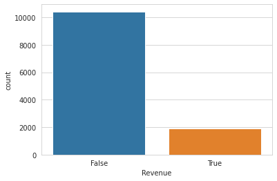

```python
import matplotlib.pyplot as plt
import seaborn as sns

sns.set_style('whitegrid')
g1 = sns.countplot(x = 'Revenue', data = df)
```

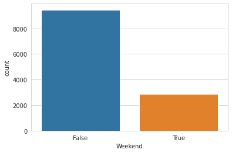

```python
g2 = sns.countplot(x = 'Weekend', data = df)
```

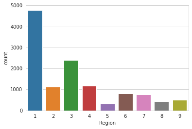

```python
g3 = sns.countplot(x = 'Region', data = df)
```

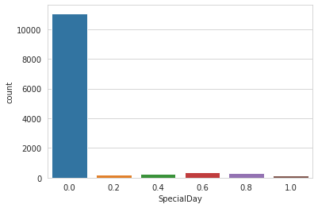

```python
g4 = sns.countplot(x = 'SpecialDay', data = df)
```

The "Special Day" feature indicates the closeness of the site visiting time to a specific special day (e.g. Mother’s Day, Valentine's Day) in which the sessions are more likely to be finalized with transaction. The value of this attribute is determined by considering the dynamics of e-commerce such as the duration between the order date and delivery date. For example, for Valentina’s day, this value takes a nonzero value between February 2 and February 12, zero before and after this date unless it is close to another special day, and its maximum value of 1 on February 8.

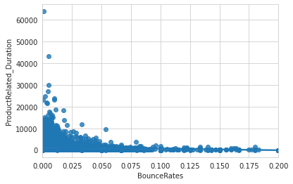

```python
g5 = sns.regplot(x = 'BounceRates',
                 y = 'ProductRelated_Duration',
                 data = df)
```

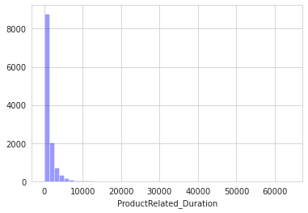

```python
g6 = sns.distplot(df.ProductRelated_Duration,
                  kde = False,
                  color = 'b')
```

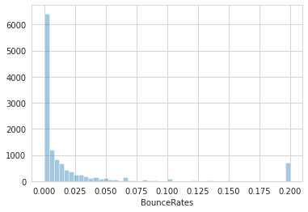

```python
g7 = sns.distplot(df.BounceRates,
                  kde = False)
```

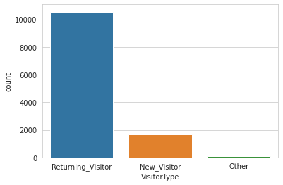

```python
g8 = sns.countplot(x = 'VisitorType', data = df)
```

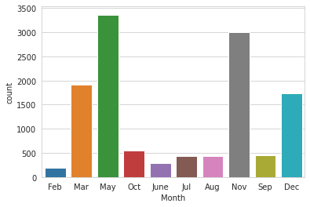

```python
g9 = sns.countplot(x = 'Month', data = df)
```

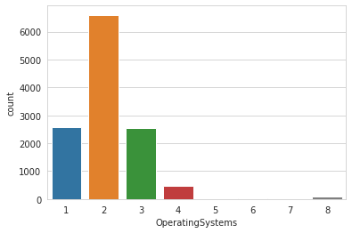

```python
g10 = sns.countplot(x = 'OperatingSystems', data = df)
```

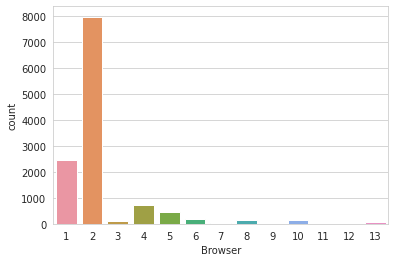

```python
g11 = sns.countplot(x = 'Browser', data = df)
```

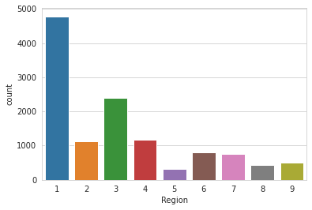

```python
g12 = sns.countplot(x = 'Region', data = df)
```

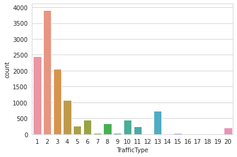

```python
g13 = sns.countplot(x = 'TrafficType', data = df)
```

## Data Preprocessing

First, we are going to create some one-hot vectors:

```python
"""
X_enc = pd.get_dummies(df, columns=['VisitorType', 'Month',])

from sklearn.preprocessing import OneHotEncoder

enc = OneHotEncoder()

# passing bridge-types-cat column (label encoded values of bridge_types)
enc_df = pd.DataFrame(enc.fit_transform(df[['VisitorType']]).toarray())

# merge with main df bridge_df on key values
df = df.join(enc_df)
df.drop('VisitorType', inplace = True, axis = 1)
"""
```

```
"\nX_enc = pd.get_dummies(df, columns=['VisitorType', 'Month',])\n\nfrom sklearn.preprocessing import OneHotEncoder\n\nenc = OneHotEncoder()\n\n# passing bridge-types-cat column (label encoded values of bridge_types)\nenc_df = pd.DataFrame(enc.fit_transform(df[['VisitorType']]).toarray())\n\n# merge…
```

```python
dummiesdf = pd.get_dummies(df['VisitorType'])
df.drop('VisitorType', inplace = True, axis = 1)
df['New_Visitor'] = dummiesdf['New_Visitor']
df['Other'] = dummiesdf['Other']
df['Returning_Visitor'] = dummiesdf['Returning_Visitor']
```

```python
dfmonth = pd.get_dummies(df['Month'])
df.drop('Month', inplace = True, axis = 1)
dfwithdummies = pd.concat([df, dfmonth], axis = 1, sort = False)
dfwithdummies.info()
```

```
<class 'pandas.core.frame.DataFrame'>
RangeIndex: 12330 entries, 0 to 12329
Data columns (total 29 columns):
 #   Column                   Non-Null Count  Dtype
---  ------                   --------------  -----
 0   Administrative           12330 non-null  int64
 1   Administrative_Duration  12330 non-null  float64
 2   Informational            12330 non-null  int64
 3   Informational_Duration   12330 non-null  float64
 4   ProductRelated           12330 non-null  int64
 5   ProductRelated_Duration  12330 non-null  float64
 6   BounceRates              12330 non-null  float64
 7   ExitRates                12330 non-null  float64
 8   PageValues               12330 non-null  float64
 9   SpecialDay               12330 non-null  float64
```

[output cut: 21 more lines]

```python
dfwithdummies['Class'] = df['Revenue'].astype(int)
dfwithdummies.drop('Revenue', axis = 1, inplace = True)
```

```python
dfwithdummies['Weekend'] = df['Weekend'].astype(int)
dfwithdummies.drop('Returning_Visitor', axis = 1, inplace = True)
dfcleaned = dfwithdummies.copy()
```

```python
X = dfcleaned.drop('Class', axis = 1)
Y = dfcleaned['Class'].copy()
```

```python
def AvgMinutes(Count, Duration):
    if Duration == 0:
        output = 0
    elif Duration != 0:
        output = float(Duration)/float(Count)
    return output

Columns = [['Administrative', 'Administrative_Duration'], ['Informational', 'Informational_Duration'], ['ProductRelated', 'ProductRelated_Duration']]


X['AvgAdministrative'] = X.apply(lambda x: AvgMinutes(Count = x['Administrative'], Duration = x['Administrative_Duration']), axis = 1)
X['AvgInformational'] = X.apply(lambda x: AvgMinutes(Count = x['Informational'], Duration = x['Informational_Duration']), axis = 1)
X['AvgProductRelated'] = X.apply(lambda x: AvgMinutes(Count = x['ProductRelated'], Duration = x['ProductRelated_Duration']), axis = 1)
X.drop(['Administrative', 'Administrative_Duration','Informational', 'Informational_Duration','ProductRelated', 'ProductRelated_Duration'], axis = 1, inplace = True)
```

```python
X
```

|  | BounceRates | ExitRates | PageValues | SpecialDay | OperatingSystems | Browser | Region | TrafficType | Weekend | New_Visitor | Other | Aug | Dec | Feb | Jul | June | Mar | May | Nov | Oct | Sep | AvgAdministrative | AvgInformational | AvgProductRelated |
| --- | --- | --- | --- | --- | --- | --- | --- | --- | --- | --- | --- | --- | --- | --- | --- | --- | --- | --- | --- | --- | --- | --- | --- | --- |
| 0 | 0.200000 | 0.200000 | 0.000000 | 0.0 | 1 | 1 | 1 | 1 | 0 | 0 | 0 | 0 | 0 | 1 | 0 | 0 | 0 | 0 | 0 | 0 | 0 | 0.000000 | 0.0 | 0.000000 |
| 1 | 0.000000 | 0.100000 | 0.000000 | 0.0 | 2 | 2 | 1 | 2 | 0 | 0 | 0 | 0 | 0 | 1 | 0 | 0 | 0 | 0 | 0 | 0 | 0 | 0.000000 | 0.0 | 32.000000 |
| 2 | 0.200000 | 0.200000 | 0.000000 | 0.0 | 4 | 1 | 9 | 3 | 0 | 0 | 0 | 0 | 0 | 1 | 0 | 0 | 0 | 0 | 0 | 0 | 0 | 0.000000 | 0.0 | 0.000000 |
| 3 | 0.050000 | 0.140000 | 0.000000 | 0.0 | 3 | 2 | 2 | 4 | 0 | 0 | 0 | 0 | 0 | 1 | 0 | 0 | 0 | 0 | 0 | 0 | 0 | 0.000000 | 0.0 | 1.333333 |
| 4 | 0.020000 | 0.050000 | 0.000000 | 0.0 | 3 | 3 | 1 | 4 | 1 | 0 | 0 | 0 | 0 | 1 | 0 | 0 | 0 | 0 | 0 | 0 | 0 | 0.000000 | 0.0 | 62.750000 |
| ... | ... | ... | ... | ... | ... | ... | ... | ... | ... | ... | ... | ... | ... | ... | ... | ... | ... | ... | ... | ... | ... | ... | ... | ... |
| 12325 | 0.007143 | 0.029031 | 12.241717 | 0.0 | 4 | 6 | 1 | 1 | 1 | 0 | 0 | 0 | 1 | 0 | 0 | 0 | 0 | 0 | 0 | 0 | 0 | 48.333333 | 0.0 | 33.656447 |
| 12326 | 0.000000 | 0.021333 | 0.000000 | 0.0 | 3 | 2 | 1 | 8 | 1 | 0 | 0 | 0 | 0 | 0 | 0 | 0 | 0 | 0 | 1 | 0 | 0 | 0.000000 | 0.0 | 93.150000 |
| 12327 | 0.083333 | 0.086667 | 0.000000 | 0.0 | 3 | 2 | 1 | 13 | 1 | 0 | 0 | 0 | 0 | 0 | 0 | 0 | 0 | 0 | 1 | 0 | 0 | 0.000000 | 0.0 | 30.708333 |
| 12328 | 0.000000 | 0.021053 | 0.000000 | 0.0 | 2 | 2 | 3 | 11 | 0 | 0 | 0 | 0 | 0 | 0 | 0 | 0 | 0 | 0 | 1 | 0 | 0 | 18.750000 | 0.0 | 23.066667 |
| 12329 | 0.000000 | 0.066667 | 0.000000 | 0.0 | 3 | 2 | 1 | 2 | 1 | 1 | 0 | 0 | 0 | 0 | 0 | 0 | 0 | 0 | 1 | 0 | 0 | 0.000000 | 0.0 | 7.083333 |

12330 rows × 24 columns

```python
# Scaling to normalize data
from sklearn.preprocessing import RobustScaler, StandardScaler, MinMaxScaler, OneHotEncoder

X_copy = X.copy()
rc = RobustScaler()
X_rc=rc.fit_transform(X_copy)
X_rc=pd.DataFrame(X_rc,columns=X.columns)
```

```python
online_shopper_intention = pd.concat([X_rc, Y], axis = 1)
online_shopper_intention.to_csv('cleaned_online_shopper_intention.csv', index = False)
```

```python
X_rc.to_csv(r'X_rc.csv', index = True)
Y.to_csv(r'Y.csv', index = True)
```

[output not shown]

```python
cor = X_rc.corr()
```

```python
import seaborn as sns
sns.heatmap(cor, xticklabels=cor.columns, yticklabels=cor.columns)
```

[output not shown]

## Modelling

```python
#X_rc = pd.read_csv('/content/drive/My Drive/AutoML /X_rc.csv')
#Y = pd.read_csv('/content/drive/My Drive/AutoML /Y.csv')
```

```python
import time
import numpy as np
import pandas as pd
from sklearn.model_selection import GridSearchCV, train_test_split
from sklearn.metrics import accuracy_score, confusion_matrix, f1_score, recall_score, precision_score, roc_auc_score, plot_roc_curve
import pickle

X_train, X_test, y_train, y_test = train_test_split(X_rc, Y, test_size = 0.2, random_state = 99)

total_len = X_train.shape[0]
split = [100, 300, 500, 1000, 3000, 5000, total_len]
```

### Linear model with all features

#### Model training & Fine-tuning

```python
from sklearn import linear_model

params_LM = {
    "loss" : ["hinge", "log", "squared_hinge", "modified_huber"],
    "alpha" : [0.0001, 0.001, 0.01, 0.1],
    "penalty" : ["l2", "l1", "none"],
}
```

```python
'''
time_spend_LM = {}
time_spend_finetuned_LM = {}
accuracy_LM = {}            # ACCURACY = (TP + TN)/(TP + TN + FP + FN)
confusion_matrix_LM = {}
f1_score_LM = {}            # F1 = 2 * (PRECISION * RECALL)/(PRECISION + RECALL)`
recall_LM = {}              # RECALL = TP/(TP + FN)
precision_LM = {}           # PRECISION = TP/(TP + FP)
roc_auc_score_LM = {}

for i in split:
  X = X_train.iloc[:i, :]
  y = y_train.iloc[:i]

  time0 = time.perf_counter()
  model = linear_model.SGDClassifier(random_state = 99, max_iter = 10000)
  model.fit(X, y)
  time1 = time.perf_counter()
  time_spend_LM[i] = time1 - time0

  time0 = time.perf_counter()
  model = linear_model.SGDClassifier(max_iter=10000)
  model = GridSearchCV(model, param_grid=params_LM).fit(X,y)
  time1 = time.perf_counter()
  time_spend_finetuned_LM[i] = time1 - time0

  filename = 'lm_SGDClassifier_{size}.pkl'.format(size = i)
  pickle.dump(model, open(filename, 'wb'))

  y_pred_LM = model.predict(X_test)

  acc_LM = accuracy_score(y_test, y_pred_LM)
  cm_LM = confusion_matrix(y_test, y_pred_LM)
  f1_LM = f1_score(y_test, y_pred_LM)
  rec_LM = recall_score(y_test, y_pred_LM)
  prec_LM = precision_score(y_test, y_pred_LM)
  roc_auc = roc_auc_score(y_test, y_pred_LM)

  accuracy_LM[i] = acc_LM
  confusion_matrix_LM[i] = cm_LM
  f1_score_LM[i] = f1_LM
  recall_LM[i] = rec_LM
  precision_LM[i] = prec_LM
  roc_auc_score_LM[i] = roc_auc
'''
  #lm_disp = plot_roc_curve(model, X_test, y_test)
  #plt.show()
```

```
"\ntime_spend_LM = {}\ntime_spend_finetuned_LM = {}\naccuracy_LM = {}            # ACCURACY = (TP + TN)/(TP + TN + FP + FN)\nconfusion_matrix_LM = {}\nf1_score_LM = {}            # F1 = 2 * (PRECISION * RECALL)/(PRECISION + RECALL)`\nrecall_LM = {}              # RECALL = TP/(TP + FN)\nprecision_LM …
```

```python
rep = 10
num_dataset = len(split)

time_spend_matrix = pd.DataFrame(np.zeros((rep, num_dataset)), columns = split)
accuracy_matrix = pd.DataFrame(np.zeros((rep,num_dataset)), columns = split)
recall_matrix = pd.DataFrame(np.zeros((rep,num_dataset)), columns = split)
confusion_matrix = pd.DataFrame(np.zeros((rep,num_dataset)), columns = split)
precision_matrix = pd.DataFrame(np.zeros((rep,num_dataset)), columns = split)
roc_auc_matrix = pd.DataFrame(np.zeros((rep, num_dataset)), columns = split)

avg_time_spend = {}
avg_acc = {}
avg_recall = {}
avg_precision = {}
avg_roc_auc = {}
```

```python
  j = total_len
  %cd /content/drive/My Drive/AutoML /LM/model/all

  data = pd.concat([X_train, y_train], axis=1)
  data = data.sample(frac = 1)
  X = data.iloc[:j,:].drop('Class', axis = 1)
  y = data.iloc[:j]['Class']

  for i in range(rep):
      time0 = time.perf_counter()
      model = linear_model.SGDClassifier()
      model = GridSearchCV(model, param_grid=params_LM,cv=5, n_jobs=-1, verbose=2).fit(X,y)
      time1 = time.perf_counter()
      time_spend = time1-time0

      filename = 'lm_SGDClassifier_{size}_{iter}.pkl'.format(size = j, iter = i+1)
      pickle.dump(model, open(filename, 'wb'))

      y_pred_LM = model.predict(X_test)

      accuracy = accuracy_score(y_test, y_pred_LM)
      print('iter:{}, sample:{}, acc:{}'.format(i+1, j, accuracy))
      tpr = recall_score(y_test, y_pred_LM)
      precision = precision_score(y_test, y_pred_LM)
      roc_auc = roc_auc_score(y_test, y_pred_LM)

      time_spend_matrix.loc[i,j] = time_spend
      accuracy_matrix.loc[i,j] = accuracy
      recall_matrix.loc[i,j] = tpr
      precision_matrix.loc[i,j] = precision
      roc_auc_matrix.loc[i,j] = roc_auc

  avg_time_spend[j] = time_spend_matrix.loc[:,j].mean()
  avg_acc[j] = accuracy_matrix.loc[:,j].mean()
  avg_recall[j] = recall_matrix.loc[:,j].mean()
  avg_precision[j] = precision_matrix.loc[:,j].mean()
  avg_roc_auc[j] = roc_auc_matrix.loc[:,j].mean()
```

```
/content/drive/My Drive/AutoML /LM/model/all
Fitting 5 folds for each of 48 candidates, totalling 240 fits
```

```
[Parallel(n_jobs=-1)]: Using backend LokyBackend with 2 concurrent workers.
[Parallel(n_jobs=-1)]: Done 128 tasks      | elapsed:    4.5s
[Parallel(n_jobs=-1)]: Done 240 out of 240 | elapsed:   10.5s finished
```

```
iter:1, sample:9864, acc:0.8937550689375506
Fitting 5 folds for each of 48 candidates, totalling 240 fits
```

```
[Parallel(n_jobs=-1)]: Using backend LokyBackend with 2 concurrent workers.
[Parallel(n_jobs=-1)]: Done 128 tasks      | elapsed:    4.6s
[Parallel(n_jobs=-1)]: Done 240 out of 240 | elapsed:   10.0s finished
```

```
iter:2, sample:9864, acc:0.8795620437956204
Fitting 5 folds for each of 48 candidates, totalling 240 fits
```

```
[Parallel(n_jobs=-1)]: Using backend LokyBackend with 2 concurrent workers.
[Parallel(n_jobs=-1)]: Done 128 tasks      | elapsed:    4.5s
[Parallel(n_jobs=-1)]: Done 240 out of 240 | elapsed:   10.7s finished
[Parallel(n_jobs=-1)]: Using backend LokyBackend with 2 concurrent workers.
```

```
iter:3, sample:9864, acc:0.889294403892944
Fitting 5 folds for each of 48 candidates, totalling 240 fits
```

```
[Parallel(n_jobs=-1)]: Done 128 tasks      | elapsed:    4.8s
[Parallel(n_jobs=-1)]: Done 240 out of 240 | elapsed:   11.0s finished
[Parallel(n_jobs=-1)]: Using backend LokyBackend with 2 concurrent workers.
```

```
iter:4, sample:9864, acc:0.8905109489051095
Fitting 5 folds for each of 48 candidates, totalling 240 fits
```

```
[Parallel(n_jobs=-1)]: Done  70 tasks      | elapsed:    2.5s
[Parallel(n_jobs=-1)]: Done 240 out of 240 | elapsed:   11.0s finished
[Parallel(n_jobs=-1)]: Using backend LokyBackend with 2 concurrent workers.
```

```
iter:5, sample:9864, acc:0.8880778588807786
Fitting 5 folds for each of 48 candidates, totalling 240 fits
```

```
[Parallel(n_jobs=-1)]: Done 128 tasks      | elapsed:    5.0s
[Parallel(n_jobs=-1)]: Done 240 out of 240 | elapsed:   10.8s finished
[Parallel(n_jobs=-1)]: Using backend LokyBackend with 2 concurrent workers.
```

```
iter:6, sample:9864, acc:0.8864557988645579
Fitting 5 folds for each of 48 candidates, totalling 240 fits
```

```
[Parallel(n_jobs=-1)]: Done  70 tasks      | elapsed:    2.7s
[Parallel(n_jobs=-1)]: Done 240 out of 240 | elapsed:   10.2s finished
[Parallel(n_jobs=-1)]: Using backend LokyBackend with 2 concurrent workers.
```

```
iter:7, sample:9864, acc:0.8909164639091647
Fitting 5 folds for each of 48 candidates, totalling 240 fits
```

```
[Parallel(n_jobs=-1)]: Done 128 tasks      | elapsed:    4.6s
[Parallel(n_jobs=-1)]: Done 240 out of 240 | elapsed:   12.3s finished
[Parallel(n_jobs=-1)]: Using backend LokyBackend with 2 concurrent workers.
```

```
iter:8, sample:9864, acc:0.8978102189781022
Fitting 5 folds for each of 48 candidates, totalling 240 fits
```

```
[Parallel(n_jobs=-1)]: Done  70 tasks      | elapsed:    2.7s
[Parallel(n_jobs=-1)]: Done 240 out of 240 | elapsed:   12.1s finished
[Parallel(n_jobs=-1)]: Using backend LokyBackend with 2 concurrent workers.
```

```
iter:9, sample:9864, acc:0.894566098945661
Fitting 5 folds for each of 48 candidates, totalling 240 fits
```

```
[Parallel(n_jobs=-1)]: Done 128 tasks      | elapsed:    4.8s
```

```
iter:10, sample:9864, acc:0.8872668288726683
```

```
[Parallel(n_jobs=-1)]: Done 240 out of 240 | elapsed:   10.2s finished
```

```python
%cd /content/drive/My Drive/AutoML /LM/model performance
time_spend_matrix.to_csv(r'time spend.csv')
accuracy_matrix.to_csv(r'accuracy.csv')
recall_matrix.to_csv(r'recall.csv')
precision_matrix.to_csv(r'precision.csv')
roc_auc_matrix.to_csv(r'roc_auc.csv')
```

```
/content/drive/My Drive/AutoML /LM/model performance
```

```python
model_performance = {
    'avg_time_spend': avg_time_spend,
    'avg_accuracy': avg_acc,
    'avg_recall': avg_recall,
    'avg_precision': avg_precision,
    'avg_roc_auc': avg_roc_auc
}
model_performance = pd.DataFrame(model_performance)
model_performance.to_csv(r'avg model performance.csv')
```

```python
'''
rep = 10
num_dataset = len(split)
time_spend_matrix = pd.DataFrame(np.zeros((rep, num_dataset)), columns = split)
accuracy_matrix = pd.DataFrame(np.zeros((rep,num_dataset)), columns = split)
recall_matrix = pd.DataFrame(np.zeros((rep,num_dataset)), columns = split)
# f1_matrix = pd.DataFrame(np.zeros((rep,num_dataset)), columns = split)
precision_matrix = pd.DataFrame(np.zeros((rep,num_dataset)), columns = split)

avg_acc = {}
avg_f1 = {}
avg_recall = {}
avg_precision = {}

for j in split:
  %cd f'/content/drive/My Drive/AutoML /LM/model/{j}'
  data = pd.concat([X_train, y_train], axis=1)
  data = data.sample(frac = 1)
  X = data.iloc[:j,:].drop('Class', axis = 1)
  y = data.iloc[:j]['Class']

  for i in range(rep):
      time0 = time.perf_counter()
      model = linear_model.SGDClassifier(max_iter=500000)
      model = GridSearchCV(model, param_grid=params_LM).fit(X,y)
      time1 = time.perf_counter()
      time_spend = time1-time0

      filename = 'lm_SGDClassifier_{size}_{iter}.pkl'.format(size = j,iter = i+1)
      pickle.dump(model, open(filename, 'wb'))

      y_pred_LM = model.predict(X_test)

      accuracy = accuracy_score(y_test, y_pred_LM)
      print('iter:{}, sample:{}, acc:{}'.format(i+1, j, accuracy))
      tpr = recall_score(y_test, y_pred_LM)
      precision = precision_score(y_test, y_pred_LM)
      roc_auc = roc_auc_score(y_test, y_pred_LM)

      time_spend_matrix.loc[i,j] = time_spend
      accuracy_matrix.loc[i,j] = accuracy
      recall_matrix.loc[i,j] = tpr
      precision_matrix.loc[i,j] = precision
      roc_auc_matrix.loc[i,j] = roc_auc

  avg_time_spend[j] = time_spend_matrix.loc[:,j].mean()
  avg_acc[j] = accuracy_matrix.loc[:,j].mean()
  avg_recall[j] = recall_matrix.loc[:,j].mean()
  avg_precision[j] = recall_matrix.loc[:,j].mean()
  avg_roc_auc[j] = roc_auc_matrix.loc[:,j].mean()
'''
```

#### Visualizing model performance

```python
def plot_time(dict, model_name):
  size = list(dict.keys())
  time = list(dict.values())
  plt.plot(size, time)
  plt.xlabel('training sample size')
  plt.ylabel('time used in training (in fractional seconds)')
  plt.title('The times spent training the {model} with varying training data size'.format(model = model_name))


def plot_model_performance(dict, model_name, performance_score):
  size = list(dict.keys())
  acc = list(dict.values())
  plt.plot(size, acc)
  plt.xlabel('training sample size')
  plt.ylabel('{}'.format(performance_score))
  plt.ylim(0, 1)
  plt.title('The {model} {performance} with varying training data size'.format(
      model = model_name, performance = performance_score))
```

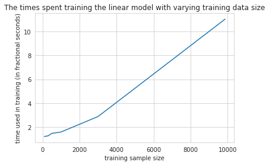

```python
plot_time(avg_time_spend, 'linear model')
```

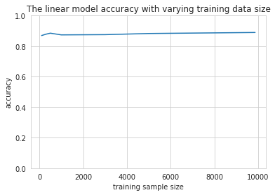

```python
plot_model_performance(avg_acc, 'linear model', 'accuracy')
```

F1 Score is the weighted average of Precision and Recall. Therefore, this score takes both false positives and false negatives into account. Intuitively it is not as easy to understand as accuracy, but F1 is usually more useful than accuracy, especially if you have an uneven class distribution. It is the harmonic mean(average) of the precision and recall. F1 Score is best if there is some sort of balance between precision (p) & recall (r) in the system. Oppositely F1 Score isn't so high if one measure is improved at the expense of the other.

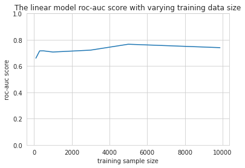

```python
plot_model_performance(avg_roc_auc, 'linear model', 'roc-auc score')
```

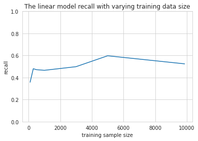

```python
plot_model_performance(avg_recall, 'linear model', 'recall')
```

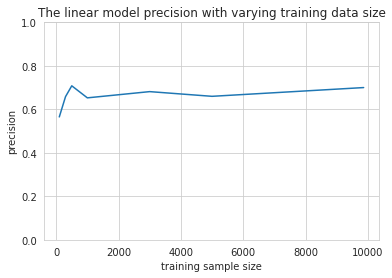

```python
plot_model_performance(avg_precision, 'linear model', 'precision')
```

### SVM with all features

#### Model training & Fine-tuning

```python
from sklearn.svm import SVC

params_SVC = {'C': [0.1, 1, 10, 100],
              'gamma': [1, 0.1, 0.01, 0.001],
              'kernel': ['rbf', 'poly', 'sigmoid']}

rep = 10
split=[100,300,500,1000,3000,5000,total_len]
num_dataset = len(split)


time_spend_matrix_SVC = pd.DataFrame(np.zeros((rep, num_dataset)), columns = split)
accuracy_matrix_SVC = pd.DataFrame(np.zeros((rep,num_dataset)), columns = split)
recall_matrix_SVC = pd.DataFrame(np.zeros((rep,num_dataset)), columns = split)
precision_matrix_SVC = pd.DataFrame(np.zeros((rep,num_dataset)), columns = split)
roc_auc_matrix_SVC = pd.DataFrame(np.zeros((rep, num_dataset)), columns = split)

avg_time_spend_SVC = {}
avg_acc_SVC = {}
avg_recall_SVC = {}
avg_precision_SVC = {}
avg_roc_auc_SVC = {}
```

```python
'''
j = total_len
%cd /content/drive/My Drive/AutoML /SVM/model/all

for i in range(rep):
  model = pickle.load(open('SVC_{size}_{iter}.pkl'.format(size = j,iter = i+1), 'rb'))
  y_pred_SVC = model.predict(X_test)

  accuracy = accuracy_score(y_test, y_pred_SVC)
  print('iter:{}, sample:{}, acc:{}'.format(i+1, j, accuracy))
  tpr = recall_score(y_test, y_pred_SVC)
  precision = precision_score(y_test, y_pred_SVC)
  roc_auc = roc_auc_score(y_test, y_pred_SVC)

  accuracy_matrix_SVC.loc[i,j] = accuracy
  recall_matrix_SVC.loc[i,j] = tpr
  precision_matrix_SVC.loc[i,j] = precision
  roc_auc_matrix_SVC.loc[i,j] = roc_auc

avg_acc_SVC[j] = accuracy_matrix_SVC.loc[:,j].mean()
avg_recall_SVC[j] = recall_matrix_SVC.loc[:,j].mean()
avg_precision_SVC[j] = precision_matrix_SVC.loc[:,j].mean()
avg_roc_auc_SVC[j] = roc_auc_matrix_SVC.loc[:,j].mean()
'''
```

[output not shown]

[output not shown]

```python
  j = total_len
  %cd /content/drive/My Drive/AutoML /SVM/model/all

  data = pd.concat([X_train, y_train], axis=1)
  data = data.sample(frac = 1)
  X = data.iloc[:j,:].drop('Class', axis = 1)
  y = data.iloc[:j]['Class']

  for i in range(4,10):
      time0 = time.perf_counter()
      model = SVC(max_iter=500000)
      model = GridSearchCV(model, param_grid=params_SVC).fit(X,y)
      time1 = time.perf_counter()
      time_spend = time1-time0

      filename = 'SVC_{size}_{iter}.pkl'.format(size = j,iter = i+1)
      pickle.dump(model, open(filename, 'wb'))

      y_pred_SVC = model.predict(X_test)

      accuracy = accuracy_score(y_test, y_pred_SVC)
      print('iter:{}, sample:{}, acc:{}'.format(i+1, j, accuracy))
      tpr = recall_score(y_test, y_pred_SVC)
      precision = precision_score(y_test, y_pred_SVC)
      roc_auc = roc_auc_score(y_test, y_pred_SVC)

      time_spend_matrix_SVC.loc[i,j] = time_spend
      accuracy_matrix_SVC.loc[i,j] = accuracy
      recall_matrix_SVC.loc[i,j] = tpr
      precision_matrix_SVC.loc[i,j] = precision
      roc_auc_matrix_SVC.loc[i,j] = roc_auc

  avg_time_spend_SVC[j] = time_spend_matrix_SVC.loc[:,j].mean()
  avg_acc_SVC[j] = accuracy_matrix_SVC.loc[:,j].mean()
  avg_recall_SVC[j] = recall_matrix_SVC.loc[:,j].mean()
  avg_precision_SVC[j] = precision_matrix_SVC.loc[:,j].mean()
  avg_roc_auc_SVC[j] = roc_auc_matrix_SVC.loc[:,j].mean()
```

```
/content/drive/My Drive/AutoML /SVM/model/all
```

[output not shown]

[output cut: 105 more lines]

[output not shown]

```
iter:5, sample:9864, acc:0.8941605839416058
```

[output not shown]

[output cut: 105 more lines]

[output not shown]

```
iter:6, sample:9864, acc:0.8941605839416058
```

[output not shown]

[output cut: 105 more lines]

[output not shown]

```
iter:7, sample:9864, acc:0.8941605839416058
```

[output not shown]

[output cut: 105 more lines]

[output not shown]

```
iter:8, sample:9864, acc:0.8941605839416058
```

[output not shown]

[output cut: 105 more lines]

[output not shown]

```
iter:9, sample:9864, acc:0.8941605839416058
```

[output not shown]

[output cut: 105 more lines]

[output not shown]

```
iter:10, sample:9864, acc:0.8941605839416058
```

```python
%cd /content/drive/My Drive/AutoML /SVM/model performance
time_spend_matrix_SVC.to_csv(r'SVC time spend.csv')
accuracy_matrix_SVC.to_csv(r'SVC accuracy.csv')
recall_matrix_SVC.to_csv(r'SVC recall.csv')
precision_matrix_SVC.to_csv(r'SVC precision.csv')
roc_auc_matrix_SVC.to_csv(r'SVC roc_auc.csv')
```

```
/content/drive/My Drive/AutoML /SVM/model performance
```

```python
model_performance_SVC = {
    'avg_time_spend': avg_time_spend_SVC,
    'avg_accuracy': avg_acc_SVC,
    'avg_recall': avg_recall_SVC,
    'avg_precision': avg_precision_SVC,
    'avg_roc_auc': avg_roc_auc_SVC
}
model_performance_SVC = pd.DataFrame(model_performance_SVC)
model_performance_SVC.to_csv(r'avg SVC performance.csv')
```

#### Visualizing Model performance

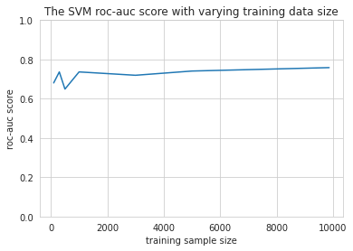

```python
plot_model_performance(avg_roc_auc_SVC, 'SVM', 'roc-auc score')
```

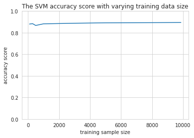

```python
plot_model_performance(avg_acc_SVC, 'SVM', 'accuracy score')
```

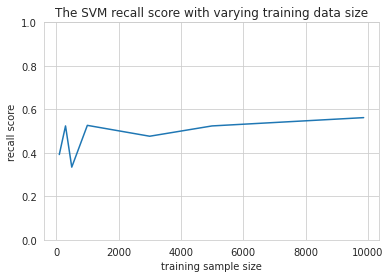

```python
plot_model_performance(avg_recall_SVC, 'SVM', 'recall score')
```

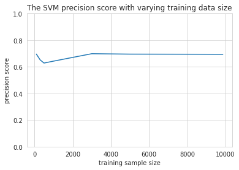

```python
plot_model_performance(avg_precision_SVC, 'SVM', 'precision score')
```

### Decision trees

#### Model training & Fine-tuning

```python
from sklearn.tree import DecisionTreeClassifier

params_DT = { 'criterion':['gini','entropy'],
              'max_depth': np.arange(3, 15)
              }

rep = 10
split=[100,300,500,1000,3000,5000,total_len]
num_dataset = len(split)

time_spend_matrix_DT = pd.DataFrame(np.zeros((rep, num_dataset)), columns = split)
accuracy_matrix_DT = pd.DataFrame(np.zeros((rep,num_dataset)), columns = split)
recall_matrix_DT = pd.DataFrame(np.zeros((rep,num_dataset)), columns = split)
precision_matrix_DT = pd.DataFrame(np.zeros((rep,num_dataset)), columns = split)
roc_auc_matrix_DT = pd.DataFrame(np.zeros((rep, num_dataset)), columns = split)

avg_time_spend_DT = {}
avg_acc_DT = {}
avg_recall_DT = {}
avg_precision_DT = {}
avg_roc_auc_DT = {}

#dt = tree.DecisionTreeClassifier(max_depth=5)
#dt = dt.fit(X_train, y_train)
```

```python
  j = total_len
  %cd /content/drive/My Drive/AutoML /Decision Tree/model/all

  data = pd.concat([X_train, y_train], axis=1)
  data = data.sample(frac = 1)
  X = data.iloc[:j,:].drop('Class', axis = 1)
  y = data.iloc[:j]['Class']

  for i in range(10):
      time0 = time.perf_counter()
      model = DecisionTreeClassifier()
      model = GridSearchCV(model, param_grid=params_DT, cv = 5, n_jobs = -1, verbose = 2).fit(X,y)
      time1 = time.perf_counter()
      time_spend = time1-time0

      filename = 'DT_{size}_{iter}.pkl'.format(size = j,iter = i+1)
      pickle.dump(model, open(filename, 'wb'))

      y_pred_DT = model.predict(X_test)

      accuracy = accuracy_score(y_test, y_pred_DT)
      print('iter:{}, sample:{}, acc:{}'.format(i+1, j, accuracy))
      tpr = recall_score(y_test, y_pred_DT)
      precision = precision_score(y_test, y_pred_DT)
      roc_auc = roc_auc_score(y_test, y_pred_DT)

      time_spend_matrix_DT.loc[i,j] = time_spend
      accuracy_matrix_DT.loc[i,j] = accuracy
      recall_matrix_DT.loc[i,j] = tpr
      precision_matrix_DT.loc[i,j] = precision
      roc_auc_matrix_DT.loc[i,j] = roc_auc

  avg_time_spend_DT[j] = time_spend_matrix_DT.loc[:,j].mean()
  avg_acc_DT[j] = accuracy_matrix_DT.loc[:,j].mean()
  avg_recall_DT[j] = recall_matrix_DT.loc[:,j].mean()
  avg_precision_DT[j] = precision_matrix_DT.loc[:,j].mean()
  avg_roc_auc_DT[j] = roc_auc_matrix_DT.loc[:,j].mean()
```

```
/content/drive/My Drive/AutoML /Decision Tree/model/all
Fitting 5 folds for each of 24 candidates, totalling 120 fits
```

```
[Parallel(n_jobs=-1)]: Using backend LokyBackend with 2 concurrent workers.
[Parallel(n_jobs=-1)]: Done 120 out of 120 | elapsed:    3.8s finished
[Parallel(n_jobs=-1)]: Using backend LokyBackend with 2 concurrent workers.
```

```
iter:1, sample:9864, acc:0.9047039740470397
Fitting 5 folds for each of 24 candidates, totalling 120 fits
```

```
[Parallel(n_jobs=-1)]: Done 120 out of 120 | elapsed:    3.8s finished
[Parallel(n_jobs=-1)]: Using backend LokyBackend with 2 concurrent workers.
```

```
iter:2, sample:9864, acc:0.9047039740470397
Fitting 5 folds for each of 24 candidates, totalling 120 fits
```

```
[Parallel(n_jobs=-1)]: Done 120 out of 120 | elapsed:    3.9s finished
[Parallel(n_jobs=-1)]: Using backend LokyBackend with 2 concurrent workers.
```

```
iter:3, sample:9864, acc:0.9047039740470397
Fitting 5 folds for each of 24 candidates, totalling 120 fits
```

```
[Parallel(n_jobs=-1)]: Done 120 out of 120 | elapsed:    3.8s finished
[Parallel(n_jobs=-1)]: Using backend LokyBackend with 2 concurrent workers.
```

```
iter:4, sample:9864, acc:0.9047039740470397
Fitting 5 folds for each of 24 candidates, totalling 120 fits
```

```
[Parallel(n_jobs=-1)]: Done 120 out of 120 | elapsed:    3.8s finished
[Parallel(n_jobs=-1)]: Using backend LokyBackend with 2 concurrent workers.
```

```
iter:5, sample:9864, acc:0.9047039740470397
Fitting 5 folds for each of 24 candidates, totalling 120 fits
```

```
[Parallel(n_jobs=-1)]: Done 120 out of 120 | elapsed:    3.9s finished
[Parallel(n_jobs=-1)]: Using backend LokyBackend with 2 concurrent workers.
```

```
iter:6, sample:9864, acc:0.9047039740470397
Fitting 5 folds for each of 24 candidates, totalling 120 fits
```

```
[Parallel(n_jobs=-1)]: Done 120 out of 120 | elapsed:    3.9s finished
[Parallel(n_jobs=-1)]: Using backend LokyBackend with 2 concurrent workers.
```

```
iter:7, sample:9864, acc:0.9047039740470397
Fitting 5 folds for each of 24 candidates, totalling 120 fits
```

```
[Parallel(n_jobs=-1)]: Done 120 out of 120 | elapsed:    3.9s finished
[Parallel(n_jobs=-1)]: Using backend LokyBackend with 2 concurrent workers.
```

```
iter:8, sample:9864, acc:0.9047039740470397
Fitting 5 folds for each of 24 candidates, totalling 120 fits
```

```
[Parallel(n_jobs=-1)]: Done 120 out of 120 | elapsed:    3.9s finished
[Parallel(n_jobs=-1)]: Using backend LokyBackend with 2 concurrent workers.
```

```
iter:9, sample:9864, acc:0.9047039740470397
Fitting 5 folds for each of 24 candidates, totalling 120 fits
iter:10, sample:9864, acc:0.9047039740470397
```

```
[Parallel(n_jobs=-1)]: Done 120 out of 120 | elapsed:    4.0s finished
```

```python
%cd /content/drive/My Drive/AutoML /Decision Tree/model performance
time_spend_matrix_DT.to_csv(r'DT time spend.csv')
accuracy_matrix_DT.to_csv(r'DT accuracy.csv')
recall_matrix_DT.to_csv(r'DT recall.csv')
precision_matrix_DT.to_csv(r'DT precision.csv')
roc_auc_matrix_DT.to_csv(r'DT roc_auc.csv')
```

```
/content/drive/My Drive/AutoML /Decision Tree/model performance
```

```python
model_performance_DT = {
    'avg_time_spend' = avg_time_spend_RF,
    'avg_accuracy': avg_acc_DT,
    'avg_recall': avg_recall_DT,
    'avg_precision': avg_precision_DT,
    'avg_roc_auc': avg_roc_auc_DT
}
model_performance_DT = pd.DataFrame(model_performance_DT)
model_performance_DT.to_csv(r'avg DT performance.csv')
```

```python
# tree.plot_tree(dt.fit(X_train, y_train))
```

#### Visualizing Model Performance

```python
'''
import graphviz
dot_data = model.export_graphviz(dt, out_file=None,
                                feature_names=X.columns,
                                class_names = y.name)
graph = graphviz.Source(dot_data)
graph.render("Shoppers_DT")
'''
```

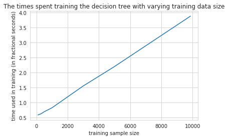

```python
plot_time(avg_time_spend_DT, 'decision tree')
```

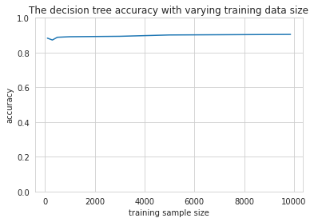

```python
plot_model_performance(avg_acc_DT, 'decision tree', 'accuracy')
```

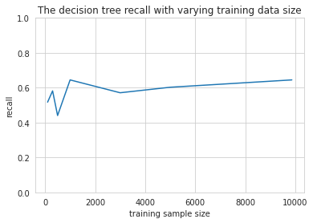

```python
plot_model_performance(avg_recall_DT, 'decision tree', 'recall')
```

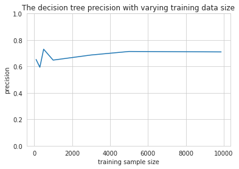

```python
plot_model_performance(avg_precision_DT, 'decision tree', 'precision')
```

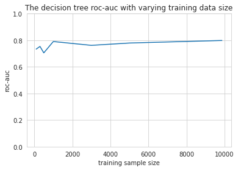

```python
plot_model_performance(avg_roc_auc_DT, 'decision tree', 'roc-auc')
```

When to use to decision tree:

1. When you want your model to be simple and explainable
2. When you want non parametric model
3. When you don't want to worry about feature selection or regularization or worry about multi-collinearity.
4. You can overfit the tree and build a model if you are sure of validation or test data set is going to be subset of training data set or almost overlapping instead of unexpected.

When to use random forest :

1. When you don't bother much about interpreting the model but want better accuracy.
2. Random forest will reduce variance part of error rather than bias part, so on a given training data set decision tree may be more accurate than a random forest. But on an unexpected validation data set, Random forest always wins in terms of accuracy.

### Random Forest with all features

#### Model Trainign & Fine-tuning

```python
from sklearn.ensemble import RandomForestClassifier

params_RF = {'bootstrap': [True, False],
             'max_depth': [5, 10, 15, 20, None],
             'max_features': ['auto', 'sqrt'],
             'n_estimators': [200, 400, 600, 800, 1000, 1200, 1400, 1600, 1800, 2000]
             }

rep = 10
split=[100,300,500,1000,3000,5000,total_len]
num_dataset = len(split)

time_spend_matrix_RF = pd.DataFrame(np.zeros((rep, num_dataset)), columns = split)
accuracy_matrix_RF = pd.DataFrame(np.zeros((rep,num_dataset)), columns = split)
recall_matrix_RF = pd.DataFrame(np.zeros((rep,num_dataset)), columns = split)
precision_matrix_RF = pd.DataFrame(np.zeros((rep,num_dataset)), columns = split)
roc_auc_matrix_RF = pd.DataFrame(np.zeros((rep, num_dataset)), columns = split)

avg_time_spend_RF = {}
avg_acc_RF = {}
avg_recall_RF = {}
avg_precision_RF = {}
avg_roc_auc_RF = {}
```

```python
X_test
```

|  | BounceRates | ExitRates | PageValues | SpecialDay | OperatingSystems | Browser | Region | TrafficType | Weekend | New_Visitor | Other | Aug | Dec | Feb | Jul | June | Mar | May | Nov | Oct | Sep | AvgAdministrative | AvgInformational | AvgProductRelated |
| --- | --- | --- | --- | --- | --- | --- | --- | --- | --- | --- | --- | --- | --- | --- | --- | --- | --- | --- | --- | --- | --- | --- | --- | --- |
| 2357 | -0.185128 | 0.228954 | 0.000000 | 0.0 | 0.0 | 4.0 | 0.333333 | -0.5 | 0.0 | 0.0 | 0.0 | 0.0 | 0.0 | 0.0 | 0.0 | 0.0 | 0.0 | 1.0 | 0.0 | 0.0 | 0.0 | 1.063555 | 0.000000 | 0.950881 |
| 6803 | 0.175353 | -0.174076 | 0.000000 | 0.0 | 0.0 | 0.0 | -0.666667 | 0.5 | 0.0 | 0.0 | 0.0 | 1.0 | 0.0 | 0.0 | 0.0 | 0.0 | 0.0 | 0.0 | 0.0 | 0.0 | 0.0 | 0.364872 | 0.000000 | 0.033008 |
| 9003 | -0.088413 | -0.287035 | 0.000000 | 0.0 | 0.0 | 0.0 | -0.666667 | 0.0 | 1.0 | 0.0 | 0.0 | 0.0 | 0.0 | 0.0 | 0.0 | 0.0 | 0.0 | 0.0 | 1.0 | 0.0 | 0.0 | -0.147440 | 31.750000 | 0.568629 |
| 11099 | -0.185128 | -0.529179 | 0.000000 | 0.0 | 0.0 | 2.0 | -0.666667 | 0.0 | 0.0 | 0.0 | 0.0 | 0.0 | 0.0 | 0.0 | 0.0 | 0.0 | 0.0 | 0.0 | 1.0 | 0.0 | 0.0 | 1.255747 | 0.000000 | 0.439683 |
| 11897 | -0.032616 | -0.147969 | 0.000000 | 0.0 | -1.0 | -1.0 | -0.333333 | 0.0 | 0.0 | 0.0 | 0.0 | 0.0 | 1.0 | 0.0 | 0.0 | 0.0 | 0.0 | 0.0 | 0.0 | 0.0 | 0.0 | 0.614563 | 0.000000 | 0.205885 |
| ... | ... | ... | ... | ... | ... | ... | ... | ... | ... | ... | ... | ... | ... | ... | ... | ... | ... | ... | ... | ... | ... | ... | ... | ... |
| 9078 | -0.004431 | -0.153186 | 7.311892 | 0.0 | 0.0 | 0.0 | -0.666667 | 4.0 | 1.0 | 0.0 | 0.0 | 0.0 | 0.0 | 0.0 | 0.0 | 0.0 | 0.0 | 0.0 | 1.0 | 0.0 | 0.0 | 0.367374 | 0.000000 | 0.794084 |
| 10923 | 3.780162 | 3.028954 | 0.000000 | 0.0 | 1.0 | 0.0 | -0.666667 | 9.0 | 0.0 | 0.0 | 0.0 | 0.0 | 1.0 | 0.0 | 0.0 | 0.0 | 0.0 | 0.0 | 0.0 | 0.0 | 0.0 | -0.209016 | 0.000000 | -0.141173 |
| 11434 | -0.185128 | -0.369564 | 10.217712 | 0.0 | 0.0 | 0.0 | -0.666667 | 4.5 | 0.0 | 0.0 | 0.0 | 0.0 | 0.0 | 0.0 | 0.0 | 0.0 | 0.0 | 0.0 | 1.0 | 0.0 | 0.0 | 0.031515 | 3.333333 | 0.706030 |
| 5771 | 1.514282 | 2.495621 | 0.000000 | 0.0 | 0.0 | 0.0 | 1.000000 | 5.5 | 0.0 | 0.0 | 0.0 | 0.0 | 0.0 | 0.0 | 1.0 | 0.0 | 0.0 | 0.0 | 0.0 | 0.0 | 0.0 | -0.209016 | 0.000000 | -0.443828 |
| 4895 | 0.806195 | -0.237713 | 0.000000 | 0.0 | -1.0 | -1.0 | -0.666667 | 0.5 | 0.0 | 0.0 | 0.0 | 0.0 | 0.0 | 0.0 | 0.0 | 0.0 | 0.0 | 1.0 | 0.0 | 0.0 | 0.0 | 1.186707 | 0.000000 | 5.176019 |

2466 rows × 24 columns

```python
  j = 300
  %cd /content/drive/My Drive/AutoML /Random Forest/model/300

  data = pd.concat([X_train, y_train], axis=1)
  data = data.sample(frac = 1)
  X = data.iloc[:j,:].drop('Class', axis = 1)
  y = data.iloc[:j]['Class']

  for i in range(10):
      time0 = time.perf_counter()
      model = RandomForestClassifier()
      model = GridSearchCV(model, param_grid=params_RF, cv = 5, n_jobs = -1, verbose = 2).fit(X,y)
      time1 = time.perf_counter()
      time_spend = time1-time0

      filename = 'RF_{size}_{iter}.pkl'.format(size = j,iter = i+1)
      pickle.dump(model, open(filename, 'wb'))

      y_pred_RF = model.predict(X_test)

      accuracy = accuracy_score(y_test, y_pred_RF)
      print('iter:{}, sample:{}, acc:{}'.format(i+1, j, accuracy))
      tpr = recall_score(y_test, y_pred_RF)
      precision = precision_score(y_test, y_pred_RF)
      roc_auc = roc_auc_score(y_test, y_pred_RF)

      time_spend_matrix_RF.loc[i,j] = time_spend
      pd.DataFrame(time_spend_matrix_RF).to_csv(r'random forest time spend.csv')
      accuracy_matrix_RF.loc[i,j] = accuracy
      recall_matrix_RF.loc[i,j] = tpr
      precision_matrix_RF.loc[i,j] = precision
      roc_auc_matrix_RF.loc[i,j] = roc_auc

  avg_time_spend_RF[j] = time_spend_matrix_RF.loc[:,j].mean()
  avg_acc_RF[j] = accuracy_matrix_RF.loc[:,j].mean()
  avg_recall_RF[j] = recall_matrix_RF.loc[:,j].mean()
  avg_precision_RF[j] = precision_matrix_RF.loc[:,j].mean()
  avg_roc_auc_RF[j] = roc_auc_matrix_RF.loc[:,j].mean()
```

```python
%cd /content/drive/My Drive/AutoML /Random Forest/model performance
time_spend_matrix_RF.to_csv(r'RF time spend.csv')
accuracy_matrix_RF.to_csv(r'RF accuracy.csv')
recall_matrix_RF.to_csv(r'RF recall.csv')
precision_matrix_RF.to_csv(r'RF precision.csv')
roc_auc_matrix_RF.to_csv(r'RF roc_auc.csv')
```

```python
model_performance_RF = {
    'avg_time_spend': avg_time_spend_RF,
    'avg_accuracy': avg_acc_RF,
    'avg_recall': avg_recall_RF,
    'avg_precision': avg_precision_RF,
    'avg_roc_auc': avg_roc_auc_RF
}
model_performance_RF = pd.DataFrame(model_performance_RF)
model_performance_RF.to_csv(r'avg RF performance.csv')
```

### Naive Bayes

#### Model training & Fine-tuning

```python
from sklearn.naive_bayes import GaussianNB

rep = 10
split=[100,300,500,1000,3000,5000,total_len]
num_dataset = len(split)

time_spend_matrix_NB = pd.DataFrame(np.zeros((rep, num_dataset)), columns = split)
accuracy_matrix_NB = pd.DataFrame(np.zeros((rep,num_dataset)), columns = split)
recall_matrix_NB = pd.DataFrame(np.zeros((rep,num_dataset)), columns = split)
precision_matrix_NB = pd.DataFrame(np.zeros((rep,num_dataset)), columns = split)
roc_auc_matrix_NB = pd.DataFrame(np.zeros((rep, num_dataset)), columns = split)

avg_time_spend_NB = {}
avg_acc_NB = {}
avg_recall_NB = {}
avg_precision_NB = {}
avg_roc_auc_NB = {}
```

```python
for j in split:
  data = pd.concat([X_train, y_train], axis=1)
  data = data.sample(frac = 1)
  X = data.iloc[:j,:].drop('Class', axis = 1)
  y = data.iloc[:j]['Class']

  for i in range(10):
      time0 = time.perf_counter()
      model = GaussianNB()
      model = model.fit(X, y)
      time1 = time.perf_counter()
      time_spend = time1-time0

      filename = 'NB_{size}_{iter}.pkl'.format(size = j,iter = i+1)
      pickle.dump(model, open(filename, 'wb'))

      y_pred_NB = model.predict(X_test)

      accuracy = accuracy_score(y_test, y_pred_NB)
      print('iter:{}, sample:{}, acc:{}'.format(i+1, j, accuracy))
      tpr = recall_score(y_test, y_pred_NB)
      precision = precision_score(y_test, y_pred_NB)
      roc_auc = roc_auc_score(y_test, y_pred_NB)

      time_spend_matrix_NB.loc[i,j] = time_spend
      accuracy_matrix_NB.loc[i,j] = accuracy
      recall_matrix_NB.loc[i,j] = tpr
      precision_matrix_NB.loc[i,j] = precision
      roc_auc_matrix_NB.loc[i,j] = roc_auc

  avg_time_spend_NB[j] = time_spend_matrix_NB.loc[:,j].mean()
  avg_acc_NB[j] = accuracy_matrix_NB.loc[:,j].mean()
  avg_recall_NB[j] = recall_matrix_NB.loc[:,j].mean()
  avg_precision_NB[j] = precision_matrix_NB.loc[:,j].mean()
  avg_roc_auc_NB[j] = roc_auc_matrix_NB.loc[:,j].mean()
```

```
iter:1, sample:100, acc:0.527169505271695
iter:2, sample:100, acc:0.527169505271695
iter:3, sample:100, acc:0.527169505271695
iter:4, sample:100, acc:0.527169505271695
iter:5, sample:100, acc:0.527169505271695
iter:6, sample:100, acc:0.527169505271695
iter:7, sample:100, acc:0.527169505271695
iter:8, sample:100, acc:0.527169505271695
iter:9, sample:100, acc:0.527169505271695
iter:10, sample:100, acc:0.527169505271695
iter:1, sample:300, acc:0.386455798864558
iter:2, sample:300, acc:0.386455798864558
iter:3, sample:300, acc:0.386455798864558
iter:4, sample:300, acc:0.386455798864558
iter:5, sample:300, acc:0.386455798864558
iter:6, sample:300, acc:0.386455798864558
iter:7, sample:300, acc:0.386455798864558
iter:8, sample:300, acc:0.386455798864558
iter:9, sample:300, acc:0.386455798864558
iter:10, sample:300, acc:0.386455798864558
iter:1, sample:500, acc:0.6013787510137875
iter:2, sample:500, acc:0.6013787510137875
iter:3, sample:500, acc:0.6013787510137875
iter:4, sample:500, acc:0.6013787510137875
iter:5, sample:500, acc:0.6013787510137875
iter:6, sample:500, acc:0.6013787510137875
iter:7, sample:500, acc:0.6013787510137875
iter:8, sample:500, acc:0.6013787510137875
iter:9, sample:500, acc:0.6013787510137875
iter:10, sample:500, acc:0.6013787510137875
iter:1, sample:1000, acc:0.46390916463909165
iter:2, sample:1000, acc:0.46390916463909165
iter:3, sample:1000, acc:0.46390916463909165
iter:4, sample:1000, acc:0.46390916463909165
iter:5, sample:1000, acc:0.46390916463909165
iter:6, sample:1000, acc:0.46390916463909165
iter:7, sample:1000, acc:0.46390916463909165
iter:8, sample:1000, acc:0.46390916463909165
iter:9, sample:1000, acc:0.46390916463909165
iter:10, sample:1000, acc:0.46390916463909165
```

[output cut: 15 more lines]

```
iter:6, sample:5000, acc:0.6435523114355232
iter:7, sample:5000, acc:0.6435523114355232
iter:8, sample:5000, acc:0.6435523114355232
iter:9, sample:5000, acc:0.6435523114355232
iter:10, sample:5000, acc:0.6435523114355232
iter:1, sample:9864, acc:0.6508515815085159
iter:2, sample:9864, acc:0.6508515815085159
iter:3, sample:9864, acc:0.6508515815085159
iter:4, sample:9864, acc:0.6508515815085159
iter:5, sample:9864, acc:0.6508515815085159
iter:6, sample:9864, acc:0.6508515815085159
iter:7, sample:9864, acc:0.6508515815085159
iter:8, sample:9864, acc:0.6508515815085159
iter:9, sample:9864, acc:0.6508515815085159
iter:10, sample:9864, acc:0.6508515815085159
```

```python
%cd /content/drive/My Drive/AutoML /Naive Bayes/model performance
time_spend_matrix_NB.to_csv(r'NB time spend.csv')
accuracy_matrix_NB.to_csv(r'NB accuracy.csv')
recall_matrix_NB.to_csv(r'NB recall.csv')
precision_matrix_NB.to_csv(r'NB precision.csv')
roc_auc_matrix_NB.to_csv(r'NB roc_auc.csv')
```

```
/content/drive/My Drive/AutoML /Naive Bayes/model performance
```

```python
model_performance_NB = {
    'avg_time_spend': avg_time_spend_NB,
    'avg_accuracy': avg_acc_NB,
    'avg_recall': avg_recall_NB,
    'avg_precision': avg_precision_NB,
    'avg_roc_auc': avg_roc_auc_NB
}
model_performance_NB = pd.DataFrame(model_performance_NB)
model_performance_NB.to_csv(r'avg NB performance.csv')
```

```python
model_performance_NB
```

|  | avg_time_spend | avg_accuracy | avg_recall | avg_precision | avg_roc_auc |
| --- | --- | --- | --- | --- | --- |
| 100 | 0.001111 | 0.527170 | 0.892105 | 0.231557 | 0.676398 |
| 300 | 0.001030 | 0.386456 | 0.865789 | 0.183696 | 0.582463 |
| 500 | 0.000989 | 0.601379 | 0.828947 | 0.255474 | 0.694435 |
| 1000 | 0.001200 | 0.463909 | 0.934211 | 0.214891 | 0.656223 |
| 3000 | 0.001826 | 0.588808 | 0.881579 | 0.256902 | 0.708527 |
| 5000 | 0.002358 | 0.643552 | 0.865789 | 0.284356 | 0.734429 |
| 9864 | 0.004056 | 0.650852 | 0.857895 | 0.287732 | 0.735515 |

### Logistics Regression

#### Model Training & Fine-tuning

```python
from sklearn.linear_model import LogisticRegression

params_LogisticsRegression = {
    'penalty' : ['l1', 'l2'],
    'C' : np.logspace(-4, 4, 20),
    'solver' : ['liblinear']
}

rep = 10
split=[100,300,500,1000,3000,5000,total_len]
num_dataset = len(split)

time_spend_matrix_LR = pd.DataFrame(np.zeros((rep, num_dataset)), columns = split)
accuracy_matrix_LR = pd.DataFrame(np.zeros((rep,num_dataset)), columns = split)
recall_matrix_LR = pd.DataFrame(np.zeros((rep,num_dataset)), columns = split)
precision_matrix_LR = pd.DataFrame(np.zeros((rep,num_dataset)), columns = split)
roc_auc_matrix_LR = pd.DataFrame(np.zeros((rep, num_dataset)), columns = split)

avg_time_spend_LR = {}
avg_acc_LR = {}
avg_recall_LR = {}
avg_precision_LR = {}
avg_roc_auc_LR = {}
```

```python
j = total_len
%cd /content/drive/My Drive/AutoML /Logistic Regression/model/all

data = pd.concat([X_train, y_train], axis=1)
data = data.sample(frac = 1)
X = data.iloc[:j,:].drop('Class', axis = 1)
y = data.iloc[:j]['Class']

for i in range(10):
      time0 = time.perf_counter()
      model = LogisticRegression()
      model = GridSearchCV(model, param_grid=params_LogisticsRegression, cv = 5, n_jobs = -1, verbose = 2).fit(X,y)
      time1 = time.perf_counter()
      time_spend = time1-time0

      filename = 'LogisticsRegression_{size}_{iter}.pkl'.format(size = j,iter = i+1)
      pickle.dump(model, open(filename, 'wb'))

      y_pred_LR = model.predict(X_test)

      accuracy = accuracy_score(y_test, y_pred_LR)
      print('iter:{}, sample:{}, acc:{}'.format(i+1, j, accuracy))
      tpr = recall_score(y_test, y_pred_LR)
      precision = precision_score(y_test, y_pred_LR)
      roc_auc = roc_auc_score(y_test, y_pred_LR)

      time_spend_matrix_LR.loc[i,j] = time_spend
      accuracy_matrix_LR.loc[i,j] = accuracy
      recall_matrix_LR.loc[i,j] = tpr
      precision_matrix_LR.loc[i,j] = precision
      roc_auc_matrix_LR.loc[i,j] = roc_auc

avg_time_spend_LR[j] = time_spend_matrix_LR.loc[:,j].mean()
avg_acc_LR[j] = accuracy_matrix_LR.loc[:,j].mean()
avg_recall_LR[j] = recall_matrix_LR.loc[:,j].mean()
avg_precision_LR[j] = precision_matrix_LR.loc[:,j].mean()
avg_roc_auc_LR[j] = roc_auc_matrix_LR.loc[:,j].mean()
```

```
/content/drive/My Drive/AutoML /Logistic Regression/model/all
Fitting 5 folds for each of 40 candidates, totalling 200 fits
```

```
[Parallel(n_jobs=-1)]: Using backend LokyBackend with 2 concurrent workers.
[Parallel(n_jobs=-1)]: Done 179 tasks      | elapsed:    8.0s
[Parallel(n_jobs=-1)]: Done 200 out of 200 | elapsed:    8.5s finished
[Parallel(n_jobs=-1)]: Using backend LokyBackend with 2 concurrent workers.
```

```
iter:1, sample:9864, acc:0.889294403892944
Fitting 5 folds for each of 40 candidates, totalling 200 fits
```

```
[Parallel(n_jobs=-1)]: Done 179 tasks      | elapsed:    7.4s
[Parallel(n_jobs=-1)]: Done 200 out of 200 | elapsed:    7.9s finished
[Parallel(n_jobs=-1)]: Using backend LokyBackend with 2 concurrent workers.
```

```
iter:2, sample:9864, acc:0.889294403892944
Fitting 5 folds for each of 40 candidates, totalling 200 fits
```

```
[Parallel(n_jobs=-1)]: Done 165 tasks      | elapsed:    7.0s
[Parallel(n_jobs=-1)]: Done 200 out of 200 | elapsed:    7.9s finished
[Parallel(n_jobs=-1)]: Using backend LokyBackend with 2 concurrent workers.
```

```
iter:3, sample:9864, acc:0.889294403892944
Fitting 5 folds for each of 40 candidates, totalling 200 fits
```

```
[Parallel(n_jobs=-1)]: Done 193 tasks      | elapsed:    7.3s
[Parallel(n_jobs=-1)]: Done 200 out of 200 | elapsed:    7.5s finished
[Parallel(n_jobs=-1)]: Using backend LokyBackend with 2 concurrent workers.
```

```
iter:4, sample:9864, acc:0.889294403892944
Fitting 5 folds for each of 40 candidates, totalling 200 fits
```

```
[Parallel(n_jobs=-1)]: Done 165 tasks      | elapsed:    7.0s
[Parallel(n_jobs=-1)]: Done 200 out of 200 | elapsed:    8.0s finished
[Parallel(n_jobs=-1)]: Using backend LokyBackend with 2 concurrent workers.
```

```
iter:5, sample:9864, acc:0.889294403892944
Fitting 5 folds for each of 40 candidates, totalling 200 fits
```

```
[Parallel(n_jobs=-1)]: Done 193 tasks      | elapsed:    7.6s
[Parallel(n_jobs=-1)]: Done 200 out of 200 | elapsed:    7.8s finished
[Parallel(n_jobs=-1)]: Using backend LokyBackend with 2 concurrent workers.
```

```
iter:6, sample:9864, acc:0.889294403892944
Fitting 5 folds for each of 40 candidates, totalling 200 fits
```

```
[Parallel(n_jobs=-1)]: Done 193 tasks      | elapsed:    7.5s
[Parallel(n_jobs=-1)]: Done 200 out of 200 | elapsed:    7.7s finished
[Parallel(n_jobs=-1)]: Using backend LokyBackend with 2 concurrent workers.
```

```
iter:7, sample:9864, acc:0.889294403892944
Fitting 5 folds for each of 40 candidates, totalling 200 fits
```

```
[Parallel(n_jobs=-1)]: Done 158 tasks      | elapsed:    8.2s
[Parallel(n_jobs=-1)]: Done 200 out of 200 | elapsed:    9.4s finished
[Parallel(n_jobs=-1)]: Using backend LokyBackend with 2 concurrent workers.
```

```
iter:8, sample:9864, acc:0.889294403892944
Fitting 5 folds for each of 40 candidates, totalling 200 fits
```

```
[Parallel(n_jobs=-1)]: Done 179 tasks      | elapsed:    7.9s
[Parallel(n_jobs=-1)]: Done 200 out of 200 | elapsed:    8.5s finished
[Parallel(n_jobs=-1)]: Using backend LokyBackend with 2 concurrent workers.
```

```
iter:9, sample:9864, acc:0.889294403892944
Fitting 5 folds for each of 40 candidates, totalling 200 fits
```

```
[Parallel(n_jobs=-1)]: Done 179 tasks      | elapsed:    7.4s
```

```
iter:10, sample:9864, acc:0.889294403892944
```

```
[Parallel(n_jobs=-1)]: Done 200 out of 200 | elapsed:    8.0s finished
```

```python
%cd /content/drive/My Drive/AutoML /Logistic Regression/model performance
time_spend_matrix_LR.to_csv(r'LR time spend.csv')
accuracy_matrix_LR.to_csv(r'LR accuracy.csv')
recall_matrix_LR.to_csv(r'LR recall.csv')
precision_matrix_LR.to_csv(r'LR precision.csv')
roc_auc_matrix_LR.to_csv(r'LR roc_auc.csv')
```

```
/content/drive/My Drive/AutoML /Logistic Regression/model performance
```

```python
model_performance_LR = {
    'avg_time_spend': avg_time_spend_LR,
    'avg_accuracy': avg_acc_LR,
    'avg_recall': avg_recall_LR,
    'avg_precision': avg_precision_LR,
    'avg_roc_auc': avg_roc_auc_LR
}
model_performance_LR = pd.DataFrame(model_performance_LR)
model_performance_LR.to_csv(r'avg Logistics Regression performance.csv')
```

### Ridge classification

#### Model Training & Fine-tuning

```python
from sklearn.linear_model import RidgeClassifier

params_RidgeClassification = {'alpha':[1,0.1,0.01,0.001,0.0001,0]}

rep = 10
split=[100,300,500,1000,3000,5000,total_len]
num_dataset = len(split)

time_spend_matrix_RR = pd.DataFrame(np.zeros((rep, num_dataset)), columns = split)
accuracy_matrix_RR = pd.DataFrame(np.zeros((rep,num_dataset)), columns = split)
recall_matrix_RR = pd.DataFrame(np.zeros((rep,num_dataset)), columns = split)
precision_matrix_RR = pd.DataFrame(np.zeros((rep,num_dataset)), columns = split)
roc_auc_matrix_RR = pd.DataFrame(np.zeros((rep, num_dataset)), columns = split)

avg_time_spend_RR = {}
avg_acc_RR = {}
avg_recall_RR = {}
avg_precision_RR = {}
avg_roc_auc_RR = {}
```

```python
j = total_len
%cd /content/drive/My Drive/AutoML /Ridge Classifier/model/all

data = pd.concat([X_train, y_train], axis=1)
data = data.sample(frac = 1)
X = data.iloc[:j,:].drop('Class', axis = 1)
y = data.iloc[:j]['Class']

for i in range(10):
      time0 = time.perf_counter()
      model = RidgeClassifier()
      model = GridSearchCV(model, param_grid=params_RidgeClassification, cv = 5, n_jobs = -1, verbose = 2).fit(X,y)
      time1 = time.perf_counter()
      time_spend = time1-time0

      filename = 'RidgeClassification_{size}_{iter}.pkl'.format(size = j,iter = i+1)
      pickle.dump(model, open(filename, 'wb'))

      y_pred_RR = model.predict(X_test)

      accuracy = accuracy_score(y_test, y_pred_RR)
      print('iter:{}, sample:{}, acc:{}'.format(i+1, j, accuracy))
      tpr = recall_score(y_test, y_pred_RR)
      precision = precision_score(y_test, y_pred_RR)
      roc_auc = roc_auc_score(y_test, y_pred_RR)

      time_spend_matrix_RR.loc[i,j] = time_spend
      accuracy_matrix_RR.loc[i,j] = accuracy
      recall_matrix_RR.loc[i,j] = tpr
      precision_matrix_RR.loc[i,j] = precision
      roc_auc_matrix_RR.loc[i,j] = roc_auc

avg_time_spend_RR[j] = time_spend_matrix_RR.loc[:,j].mean()
avg_acc_RR[j] = accuracy_matrix_RR.loc[:,j].mean()
avg_recall_RR[j] = recall_matrix_RR.loc[:,j].mean()
avg_precision_RR[j] = precision_matrix_RR.loc[:,j].mean()
avg_roc_auc_RR[j] = roc_auc_matrix_RR.loc[:,j].mean()
```

```
/content/drive/My Drive/AutoML /Ridge Classifier/model/all
Fitting 5 folds for each of 6 candidates, totalling 30 fits
```

```
[Parallel(n_jobs=-1)]: Using backend LokyBackend with 2 concurrent workers.
[Parallel(n_jobs=-1)]: Done  30 out of  30 | elapsed:    0.4s finished
[Parallel(n_jobs=-1)]: Using backend LokyBackend with 2 concurrent workers.
```

```
iter:1, sample:9864, acc:0.8763179237631792
Fitting 5 folds for each of 6 candidates, totalling 30 fits
```

```
[Parallel(n_jobs=-1)]: Done  30 out of  30 | elapsed:    0.4s finished
[Parallel(n_jobs=-1)]: Using backend LokyBackend with 2 concurrent workers.
```

```
iter:2, sample:9864, acc:0.8763179237631792
Fitting 5 folds for each of 6 candidates, totalling 30 fits
```

```
[Parallel(n_jobs=-1)]: Done  30 out of  30 | elapsed:    0.4s finished
[Parallel(n_jobs=-1)]: Using backend LokyBackend with 2 concurrent workers.
```

```
iter:3, sample:9864, acc:0.8763179237631792
Fitting 5 folds for each of 6 candidates, totalling 30 fits
```

```
[Parallel(n_jobs=-1)]: Done  30 out of  30 | elapsed:    0.4s finished
[Parallel(n_jobs=-1)]: Using backend LokyBackend with 2 concurrent workers.
```

```
iter:4, sample:9864, acc:0.8763179237631792
Fitting 5 folds for each of 6 candidates, totalling 30 fits
```

```
[Parallel(n_jobs=-1)]: Done  30 out of  30 | elapsed:    0.3s finished
[Parallel(n_jobs=-1)]: Using backend LokyBackend with 2 concurrent workers.
```

```
iter:5, sample:9864, acc:0.8763179237631792
Fitting 5 folds for each of 6 candidates, totalling 30 fits
```

```
[Parallel(n_jobs=-1)]: Done  30 out of  30 | elapsed:    0.4s finished
[Parallel(n_jobs=-1)]: Using backend LokyBackend with 2 concurrent workers.
```

```
iter:6, sample:9864, acc:0.8763179237631792
Fitting 5 folds for each of 6 candidates, totalling 30 fits
```

```
[Parallel(n_jobs=-1)]: Done  30 out of  30 | elapsed:    0.4s finished
[Parallel(n_jobs=-1)]: Using backend LokyBackend with 2 concurrent workers.
```

```
iter:7, sample:9864, acc:0.8763179237631792
Fitting 5 folds for each of 6 candidates, totalling 30 fits
```

```
[Parallel(n_jobs=-1)]: Done  30 out of  30 | elapsed:    0.4s finished
[Parallel(n_jobs=-1)]: Using backend LokyBackend with 2 concurrent workers.
```

```
iter:8, sample:9864, acc:0.8763179237631792
Fitting 5 folds for each of 6 candidates, totalling 30 fits
```

```
[Parallel(n_jobs=-1)]: Done  30 out of  30 | elapsed:    0.4s finished
[Parallel(n_jobs=-1)]: Using backend LokyBackend with 2 concurrent workers.
```

```
iter:9, sample:9864, acc:0.8763179237631792
Fitting 5 folds for each of 6 candidates, totalling 30 fits
iter:10, sample:9864, acc:0.8763179237631792
```

```
[Parallel(n_jobs=-1)]: Done  30 out of  30 | elapsed:    0.4s finished
```

```python
%cd /content/drive/My Drive/AutoML /Ridge Classifier/model performance
time_spend_matrix_RR.to_csv(r'Ridge Classification time spend.csv')
accuracy_matrix_RR.to_csv(r'Ridge Classification accuracy.csv')
recall_matrix_RR.to_csv(r'Ridge Classification recall.csv')
precision_matrix_RR.to_csv(r'Ridge Classification precision.csv')
roc_auc_matrix_RR.to_csv(r'Ridge Classification roc_auc.csv')
```

```
/content/drive/My Drive/AutoML /Ridge Classifier/model performance
```

#### Visualizing Model Performance

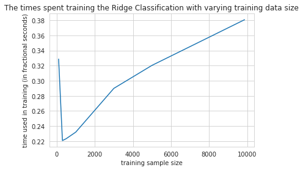

```python
plot_time(avg_time_spend_RR, 'Ridge Classification')
```

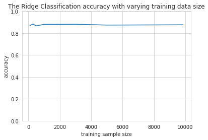

```python
plot_model_performance(avg_acc_RR, 'Ridge Classification', 'accuracy')
```

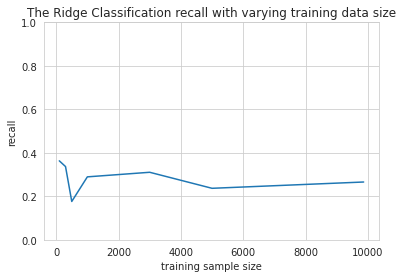

```python
plot_model_performance(avg_recall_RR, 'Ridge Classification', 'recall')
```

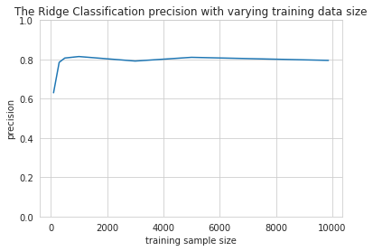

```python
plot_model_performance(avg_precision_RR, 'Ridge Classification', 'precision')
```

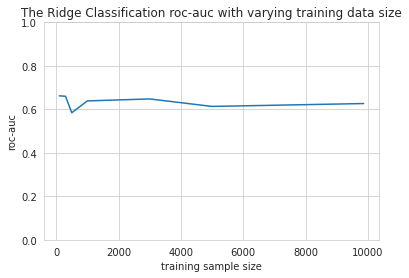

```python
plot_model_performance(avg_roc_auc_RR, 'Ridge Classification', 'roc-auc')
```

### XGBoost

#### Model Training & Fine-tuning

```python
from xgboost import XGBClassifier

params_XGBoost = {
        'learning_rate': [0.05, 0.1, 0.2],
        'min_child_weight': [1, 5, 10],
        'gamma': [0.5, 1, 1.5, 2, 5],
        'max_depth': [3, 5, 10, 15],
        'n_estimators': [150]
        }

rep = 10
split=[100,300,500,1000,3000,5000,total_len]
num_dataset = len(split)

time_spend_matrix_XGBoost = pd.DataFrame(np.zeros((rep, num_dataset)), columns = split)
accuracy_matrix_XGBoost = pd.DataFrame(np.zeros((rep,num_dataset)), columns = split)
recall_matrix_XGBoost = pd.DataFrame(np.zeros((rep,num_dataset)), columns = split)
precision_matrix_XGBoost = pd.DataFrame(np.zeros((rep,num_dataset)), columns = split)
roc_auc_matrix_XGBoost = pd.DataFrame(np.zeros((rep, num_dataset)), columns = split)

avg_time_spend_XGBoost = {}
avg_acc_XGBoost = {}
avg_recall_XGBoost = {}
avg_precision_XGBoost = {}
avg_roc_auc_XGBoost = {}
```

```python
j = total_len
%cd /content/drive/My Drive/AutoML /XGBoost/model/all

data = pd.concat([X_train, y_train], axis=1)
data = data.sample(frac = 1)
X = data.iloc[:j,:].drop('Class', axis = 1)
y = data.iloc[:j]['Class']

for i in range(10):
      time0 = time.perf_counter()
      model = XGBClassifier()
      model = GridSearchCV(model, param_grid=params_XGBoost, cv = 5, n_jobs = -1, verbose = 2).fit(X,y)
      time1 = time.perf_counter()
      time_spend = time1-time0

      filename = 'XGBoost_{size}_{iter}.pkl'.format(size = j,iter = i+1)
      pickle.dump(model, open(filename, 'wb'))

      y_pred_XGBoost = model.predict(X_test)

      accuracy = accuracy_score(y_test, y_pred_XGBoost)
      print('iter:{}, sample:{}, acc:{}'.format(i+1, j, accuracy))
      tpr = recall_score(y_test, y_pred_XGBoost)
      precision = precision_score(y_test, y_pred_XGBoost)
      roc_auc = roc_auc_score(y_test, y_pred_XGBoost)

      time_spend_matrix_XGBoost.loc[i,j] = time_spend
      accuracy_matrix_XGBoost.loc[i,j] = accuracy
      recall_matrix_XGBoost.loc[i,j] = tpr
      precision_matrix_XGBoost.loc[i,j] = precision
      roc_auc_matrix_XGBoost.loc[i,j] = roc_auc

avg_time_spend_XGBoost[j] = time_spend_matrix_XGBoost.loc[:,j].mean()
avg_acc_XGBoost[j] = accuracy_matrix_XGBoost.loc[:,j].mean()
avg_recall_XGBoost[j] = recall_matrix_XGBoost.loc[:,j].mean()
avg_precision_XGBoost[j] = precision_matrix_XGBoost.loc[:,j].mean()
avg_roc_auc_XGBoost[j] = roc_auc_matrix_XGBoost.loc[:,j].mean()
```

```
/content/drive/My Drive/AutoML /XGBoost/model/all
Fitting 5 folds for each of 180 candidates, totalling 900 fits
```

```
[Parallel(n_jobs=-1)]: Using backend LokyBackend with 2 concurrent workers.
[Parallel(n_jobs=-1)]: Done  37 tasks      | elapsed:   40.5s
[Parallel(n_jobs=-1)]: Done 158 tasks      | elapsed:  3.7min
[Parallel(n_jobs=-1)]: Done 361 tasks      | elapsed:  9.0min
[Parallel(n_jobs=-1)]: Done 644 tasks      | elapsed: 15.7min
[Parallel(n_jobs=-1)]: Done 900 out of 900 | elapsed: 22.0min finished
```

```
iter:1, sample:9864, acc:0.9055150040551501
Fitting 5 folds for each of 180 candidates, totalling 900 fits
```

```
[Parallel(n_jobs=-1)]: Using backend LokyBackend with 2 concurrent workers.
[Parallel(n_jobs=-1)]: Done  37 tasks      | elapsed:   38.5s
[Parallel(n_jobs=-1)]: Done 158 tasks      | elapsed:  3.6min
[Parallel(n_jobs=-1)]: Done 361 tasks      | elapsed:  8.7min
[Parallel(n_jobs=-1)]: Done 644 tasks      | elapsed: 15.3min
[Parallel(n_jobs=-1)]: Done 900 out of 900 | elapsed: 21.6min finished
```

```
iter:2, sample:9864, acc:0.9055150040551501
Fitting 5 folds for each of 180 candidates, totalling 900 fits
```

```
[Parallel(n_jobs=-1)]: Using backend LokyBackend with 2 concurrent workers.
[Parallel(n_jobs=-1)]: Done  37 tasks      | elapsed:   38.8s
[Parallel(n_jobs=-1)]: Done 158 tasks      | elapsed:  3.6min
[Parallel(n_jobs=-1)]: Done 361 tasks      | elapsed:  8.6min
[Parallel(n_jobs=-1)]: Done 644 tasks      | elapsed: 15.2min
[Parallel(n_jobs=-1)]: Done 900 out of 900 | elapsed: 21.4min finished
```

```
iter:3, sample:9864, acc:0.9055150040551501
Fitting 5 folds for each of 180 candidates, totalling 900 fits
```

```
[Parallel(n_jobs=-1)]: Using backend LokyBackend with 2 concurrent workers.
[Parallel(n_jobs=-1)]: Done  37 tasks      | elapsed:   38.6s
[Parallel(n_jobs=-1)]: Done 158 tasks      | elapsed:  3.5min
[Parallel(n_jobs=-1)]: Done 361 tasks      | elapsed:  8.6min
[Parallel(n_jobs=-1)]: Done 644 tasks      | elapsed: 15.1min
[Parallel(n_jobs=-1)]: Done 900 out of 900 | elapsed: 21.4min finished
```

```
iter:4, sample:9864, acc:0.9055150040551501
Fitting 5 folds for each of 180 candidates, totalling 900 fits
```

```
[Parallel(n_jobs=-1)]: Using backend LokyBackend with 2 concurrent workers.
[Parallel(n_jobs=-1)]: Done  37 tasks      | elapsed:   38.5s
[Parallel(n_jobs=-1)]: Done 158 tasks      | elapsed:  3.5min
[Parallel(n_jobs=-1)]: Done 361 tasks      | elapsed:  8.6min
[Parallel(n_jobs=-1)]: Done 644 tasks      | elapsed: 15.1min
[Parallel(n_jobs=-1)]: Done 900 out of 900 | elapsed: 21.3min finished
```

```
iter:5, sample:9864, acc:0.9055150040551501
Fitting 5 folds for each of 180 candidates, totalling 900 fits
```

```
[Parallel(n_jobs=-1)]: Using backend LokyBackend with 2 concurrent workers.
[Parallel(n_jobs=-1)]: Done  37 tasks      | elapsed:   38.7s
[Parallel(n_jobs=-1)]: Done 158 tasks      | elapsed:  3.6min
[Parallel(n_jobs=-1)]: Done 361 tasks      | elapsed:  8.6min
[Parallel(n_jobs=-1)]: Done 644 tasks      | elapsed: 15.1min
[Parallel(n_jobs=-1)]: Done 900 out of 900 | elapsed: 21.3min finished
```

```
iter:6, sample:9864, acc:0.9055150040551501
Fitting 5 folds for each of 180 candidates, totalling 900 fits
```

```
[Parallel(n_jobs=-1)]: Using backend LokyBackend with 2 concurrent workers.
[Parallel(n_jobs=-1)]: Done  37 tasks      | elapsed:   38.3s
[Parallel(n_jobs=-1)]: Done 158 tasks      | elapsed:  3.5min
[Parallel(n_jobs=-1)]: Done 361 tasks      | elapsed:  8.6min
[Parallel(n_jobs=-1)]: Done 644 tasks      | elapsed: 15.0min
[Parallel(n_jobs=-1)]: Done 900 out of 900 | elapsed: 21.2min finished
```

```
iter:7, sample:9864, acc:0.9055150040551501
Fitting 5 folds for each of 180 candidates, totalling 900 fits
```

```
[Parallel(n_jobs=-1)]: Using backend LokyBackend with 2 concurrent workers.
[Parallel(n_jobs=-1)]: Done  37 tasks      | elapsed:   38.4s
[Parallel(n_jobs=-1)]: Done 158 tasks      | elapsed:  3.5min
[Parallel(n_jobs=-1)]: Done 361 tasks      | elapsed:  8.6min
[Parallel(n_jobs=-1)]: Done 644 tasks      | elapsed: 15.0min
[Parallel(n_jobs=-1)]: Done 900 out of 900 | elapsed: 21.2min finished
```

```
iter:8, sample:9864, acc:0.9055150040551501
Fitting 5 folds for each of 180 candidates, totalling 900 fits
```

```
[Parallel(n_jobs=-1)]: Using backend LokyBackend with 2 concurrent workers.
[Parallel(n_jobs=-1)]: Done  37 tasks      | elapsed:   38.6s
[Parallel(n_jobs=-1)]: Done 158 tasks      | elapsed:  3.5min
[Parallel(n_jobs=-1)]: Done 361 tasks      | elapsed:  8.6min
[Parallel(n_jobs=-1)]: Done 644 tasks      | elapsed: 15.1min
[Parallel(n_jobs=-1)]: Done 900 out of 900 | elapsed: 21.3min finished
```

```
iter:9, sample:9864, acc:0.9055150040551501
Fitting 5 folds for each of 180 candidates, totalling 900 fits
```

```
[Parallel(n_jobs=-1)]: Using backend LokyBackend with 2 concurrent workers.
[Parallel(n_jobs=-1)]: Done  37 tasks      | elapsed:   38.8s
[Parallel(n_jobs=-1)]: Done 158 tasks      | elapsed:  3.5min
[Parallel(n_jobs=-1)]: Done 361 tasks      | elapsed:  8.6min
[Parallel(n_jobs=-1)]: Done 644 tasks      | elapsed: 15.0min
[Parallel(n_jobs=-1)]: Done 900 out of 900 | elapsed: 21.2min finished
```

```
iter:10, sample:9864, acc:0.9055150040551501
```

```python
%cd /content/drive/My Drive/AutoML /XGBoost/model performance
time_spend_matrix_XGBoost.to_csv(r'XGBoost time spend.csv')
accuracy_matrix_XGBoost.to_csv(r'XGBoost accuracy.csv')
recall_matrix_XGBoost.to_csv(r'XGBoost recall.csv')
precision_matrix_XGBoost.to_csv(r'XGBoost precision.csv')
roc_auc_matrix_XGBoost.to_csv(r'XGBoost roc_auc.csv')
```

```
/content/drive/My Drive/AutoML /XGBoost/model performance
```

```python
model_performance_XGBoost = {
    'avg_time_spend': avg_time_spend_XGBoost,
    'avg_accuracy': avg_acc_XGBoost,
    'avg_recall': avg_recall_XGBoost,
    'avg_precision': avg_precision_XGBoost,
    'avg_roc_auc': avg_roc_auc_XGBoost
}
model_performance_XGBoost = pd.DataFrame(model_performance_XGBoost)
model_performance_XGBoost.to_csv(r'avg XGBoost performance.csv')
```

#### Vilualizing Model Performance

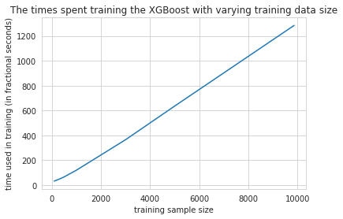

```python
plot_time(avg_time_spend_XGBoost, 'XGBoost')
```

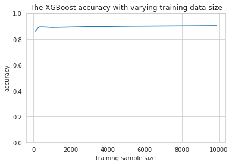

```python
plot_model_performance(avg_acc_XGBoost, 'XGBoost', 'accuracy')
```

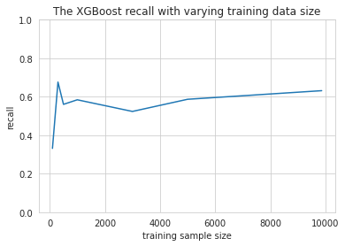

```python
plot_model_performance(avg_recall_XGBoost, 'XGBoost', 'recall')
```

### AdaBoost

#### Model Training & Fine-tuning

```python
from sklearn.ensemble import AdaBoostClassifier

params_AdaBoost = {
        'learning_rate': [.001,0.01,.1],
        'n_estimators': [500,1000,2000]
        }

rep = 10
total_len = X_train.shape[0]
split=[100,300,500,1000,3000,5000,total_len]
num_dataset = len(split)

time_spend_matrix_AdaBoost = pd.DataFrame(np.zeros((rep, num_dataset)), columns = split)
accuracy_matrix_AdaBoost = pd.DataFrame(np.zeros((rep,num_dataset)), columns = split)
recall_matrix_AdaBoost = pd.DataFrame(np.zeros((rep,num_dataset)), columns = split)
precision_matrix_AdaBoost = pd.DataFrame(np.zeros((rep,num_dataset)), columns = split)
roc_auc_matrix_AdaBoost = pd.DataFrame(np.zeros((rep, num_dataset)), columns = split)

avg_time_spend_AdaBoost = {}
avg_acc_AdaBoost = {}
avg_recall_AdaBoost = {}
avg_precision_AdaBoost = {}
avg_roc_auc_AdaBoost = {}
```

```python
for j in split:

    data = pd.concat([X_train, y_train], axis=1)
    data = data.sample(frac = 1)
    X = data.iloc[:j,:].drop('Class', axis = 1)
    y = data.iloc[:j]['Class']

    for i in range(10):
      time0 = time.perf_counter()
      model = AdaBoostClassifier()
      model = GridSearchCV(model, param_grid=params_AdaBoost, cv = 5, n_jobs = -1, verbose = 2).fit(X,y)
      time1 = time.perf_counter()
      time_spend = time1-time0

      filename = 'AdaBoost_{size}_{iter}.pkl'.format(size = j,iter = i+1)
      pickle.dump(model, open(filename, 'wb'))

      y_pred_AdaBoost = model.predict(X_test)

      accuracy = accuracy_score(y_test, y_pred_AdaBoost)
      print('iter:{}, sample:{}, acc:{}'.format(i+1, j, accuracy))
      tpr = recall_score(y_test, y_pred_AdaBoost)
      precision = precision_score(y_test, y_pred_AdaBoost)
      roc_auc = roc_auc_score(y_test, y_pred_AdaBoost)

      time_spend_matrix_AdaBoost.loc[i,j] = time_spend
      accuracy_matrix_AdaBoost.loc[i,j] = accuracy
      recall_matrix_AdaBoost.loc[i,j] = tpr
      precision_matrix_AdaBoost.loc[i,j] = precision
      roc_auc_matrix_AdaBoost.loc[i,j] = roc_auc

    avg_time_spend_AdaBoost[j] = time_spend_matrix_AdaBoost.loc[:,j].mean()
    avg_acc_AdaBoost[j] = accuracy_matrix_AdaBoost.loc[:,j].mean()
    avg_recall_AdaBoost[j] = recall_matrix_AdaBoost.loc[:,j].mean()
    avg_precision_AdaBoost[j] = precision_matrix_AdaBoost.loc[:,j].mean()
    avg_roc_auc_AdaBoost[j] = roc_auc_matrix_AdaBoost.loc[:,j].mean()
```

#### Visualizing Model Performance

```python
time_spend_matrix_AdaBoost = pd.read_csv('/content/drive/My Drive/AutoML /AdaBoost/model performance/AdaBoost time spend.csv', index_col = 0)
accuracy_matrix_AdaBoost = pd.read_csv('/content/drive/My Drive/AutoML /AdaBoost/model performance/AdaBoost accuracy.csv', index_col = 0)
recall_matrix_AdaBoost = pd.read_csv('/content/drive/My Drive/AutoML /AdaBoost/model performance/AdaBoost recall.csv', index_col = 0)
precision_matrix_AdaBoost = pd.read_csv('/content/drive/My Drive/AutoML /AdaBoost/model performance/AdaBoost precision.csv', index_col = 0)
roc_auc_matrix_AdaBoost = pd.read_csv('/content/drive/My Drive/AutoML /AdaBoost/model performance/AdaBoost roc_auc.csv', index_col = 0)
```

```python
time_spend_matrix_AdaBoost
```

|  | 100 | 300 | 500 | 1000 | 3000 | 5000 | 9864 |
| --- | --- | --- | --- | --- | --- | --- | --- |
| 0 | 0.0 | 12.847195 | 14.419526 | 17.391916 | 35.535458 | 54.631617 | 86.451465 |
| 1 | 0.0 | 11.443180 | 14.512754 | 17.096090 | 36.227459 | 52.420892 | 86.849527 |
| 2 | 0.0 | 11.388307 | 14.332586 | 17.313794 | 36.221230 | 54.675136 | 86.542519 |
| 3 | 0.0 | 11.307346 | 14.500466 | 17.789581 | 35.449814 | 52.662889 | 92.308609 |
| 4 | 0.0 | 11.365219 | 14.432701 | 17.305827 | 36.610489 | 53.537653 | 88.828439 |
| 5 | 0.0 | 12.011731 | 14.495282 | 17.348517 | 35.455521 | 53.620169 | 89.368870 |
| 6 | 0.0 | 11.755264 | 14.573423 | 17.107458 | 36.254566 | 53.915961 | 89.397277 |
| 7 | 0.0 | 11.739748 | 14.416165 | 17.192272 | 34.836826 | 54.711549 | 89.211863 |
| 8 | 0.0 | 11.448047 | 14.856745 | 17.348055 | 35.506107 | 52.880242 | 91.968744 |
| 9 | 0.0 | 11.417129 | 14.518096 | 17.335014 | 35.484598 | 52.334831 | 89.166210 |

```python
%cd /content/drive/My Drive/AutoML /
!pip freeze > requirements.txt
```

```
/content/drive/My Drive/AutoML
```